# CAOS-12 signal

## Intro to IPC

Помните syscall?

Мы его используем, когда нам необходимо как-то провзоимодействовать с внешним миром (с ядром)

Но что делать, если какой-то другой процесс хочет взаимодействовать с нами?

это просто сам 'факт' коммуникации

Для взаимодействия между процессами существует целое семейство инструментов - IPC (Inter-Process Communication)

Конкретно сегодня поговорим про сигналы - маленькие короткие сообщения, которые передают сам факт коммуникации

Можно сравнить с get-запросами - запросами без тела

Так же и у сигналов - нет тела сообщения, только номер сигнала (аля заголовок)

## Как это устроено

### Доставка сигнала

У каждого процесса есть вектор (маска) сигналов

| №0 | №1 | №2 | №3 | №4 | ... | №N |
| --- | --- | --- | --- | --- | --- | --- |
| 0 | 0 | 1 | 1 | 0 |  | 0 |

У каждого сигнала есть свой номер

Если бит выставлен в 1 -- сигнал пришел, в 0 -- не пришел

**Вопрос:** что будет если один и тот же сигнал прийдет дважды

### Обработка сигнала

У каждого сигнала есть свой обработчик - функция, которая вызывается когда сигнал приходит

**Как именно это все работает?**

Сам процесс, как бы ему этого не хотелось, работает не постоянно

Ядро то ставит его на выполнение, то снимает

Вот именно в момент постановки на выполнение, ядро проверяет вектор прерываний на наличие в нем 'единичек'

### Пример

Учимся убивать использовать команду kill

```
NAME
    kill - terminate a process
...
DESCRIPTION
    The command kill sends the specified signal to the specified processes or process groups.
```

```
[danila@archlinux ~]
$ ps -a | grep yes
 147783 pts/3    00:00:08 yes
```

Ну и пошлем сигнал через kill

```
[danila@archlinux ~]
$ kill -SIGTERM 147783
[danila@archlinux ~]
$
[1]  + terminated  yes x > /dev/null
```

По умолчанию команда kill посылает сигнал именно SIGTERM. Обычно SIGTERM используют, чтобы 'мягко' завершить работу программы

### Так, ладно, а что может сделать процесс после получения сигнала?

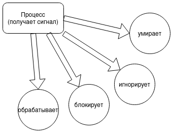

- умирает - очевидно
- игнорирует - ничего не делает
- блокирует - делает вид, что сигнала не было (поговорим вместе с **rt сигналами**)
- обрабатывает - а вот тут подробнее

> Blocking is different from ignoring. You ignore a signal by installing SIG_IGN with sigaction().

After a signal is generated by the kernel or a process, the kernel makes it pending to some process(es). The signal is said to be delivered to a process once the process acts on the signal. A process may block a signal, which leaves the signal pending until it is unblocked. A signal which is not blocked will be delivered immediately. The signal mask specifies which signals are blocked. A process can determine which signals are pending.

### Обработчик сигнала

Обработчик (или handler) сигнала имеет вид:

```
void handler(int signal_number) {
...
}
```

- возвращает void - тут вроде очев
- принимает номер сигнала - один и тот же хендлер может быть у нескольких сигналов

### Что можно использовать в обработчике

Тут у нас возникают проблемы с (внезапно) многопоточностью

Вот была программа

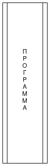

А потом прилетел сигнал и в программу вклинился обработчик

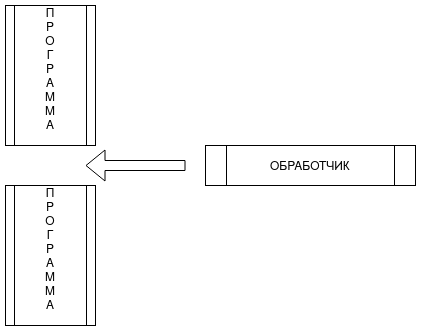

Не совсем многопоточность, но kind of

Есть по сути два потока выполнения - сама программа и обработчик

Да, они **НЕ РАБОТАЮТ ОДНОВРЕМЕННО**, но первый поток (программа) встает на паузу в случайный (для нас) момент времени

Из этого вытикает интересное понятие - **async-signal-safe functions** (`man signal-safety`)

По сути дословно значит - функции, которые можно применять в signal handler-е

Если их кратко обобщить - это функции, которые не могут заблокироваться

Например там **нельзя** использовать `printf`, но **можно** `read` и `write` (список того, что можно есть в `man signal-safety`)

## Погнали кодить!))

### ПРЕАМБУЛА

В линуксе есть 2 способа обрабатывать сигналы

`signal (man 2 signal)` и `sigaction (man 2 sigaction)`

Первый способ **устарел**, за него будем бить.

Про него многие на рассказывают (я тоже не буду)

### Пример 1 - игнорируем сигналы

В `sigaction` управление обработчиками происходит при помощи `struct sigaction` и функцией `sigaction` (обо всем можно почитать в `man 2 sigaction`)

Кратко про флаг SA_RESTART

> Системные вызовы, которые будут прерваны исполнением

[output not shown]

```python
%%writefile example1.c

#include <stdio.h>
#include <signal.h>
#include <unistd.h>

int main() {
    struct sigaction sa = {
        .sa_handler = SIG_IGN,
        .sa_flags = SA_RESTART,
    };

    sigaction(SIGTERM, &sa, NULL);

    // pause - спим, пока не прилетит любой сигнал
    pause();
    printf("<unreachable>");

    return 0;
}
```

```
Overwriting example1.c
```

```python
!# лучше в терминале
!gcc example1.c -o example1
!./example1
```

```
[danila@archlinux ~/caos/12-signal]
$ ps -A | grep example
 153842 pts/0    00:00:00 example1

[danila@archlinux ~/caos/12-signal]
$ kill -SIGTERM 153842
# ничего не произошло (сигнал проигнорирован)

[danila@archlinux ~/caos/12-signal]
$ kill -SIGUSR1 153842
# процесс умер
```

### Пример 2 - пустой обработчик

```python
%%writefile example2.c

#include <stdio.h>
#include <signal.h>
#include <unistd.h>

void handler(int sig_num) {
    // nop
}

int main() {
    struct sigaction sa = {
        .sa_handler = handler,
        .sa_flags = SA_RESTART,
    };

    sigaction(SIGTERM, &sa, NULL);

    // pause - спим, пока не прилетит любой сигнал
    pause();
    printf("now reachable");

    return 0;
}
```

```
Overwriting example2.c
```

```python
!# лучше в терминале
!gcc example2.c -o example2
!./example2 &; killall example2
```

```
now reachable
```

Объяснение - отправляем SIGTERM, вызывается обработчик, потом мы ПРОСЫПАЕМСЯ

### Пример 3 - считаем количество сигналов

```python
%%writefile example3.c

#include <stdio.h>
#include <signal.h>
#include <unistd.h>

// volatile - ОБЯЗАТЕЛЬНО!
volatile int usr1_cnt = 0;
volatile int usr2_cnt = 0;

volatile int is_running = 1;

void handler(int sig_num) {
    if (sig_num == SIGUSR1) {
        ++usr1_cnt;
    } else if (sig_num == SIGUSR2) {
        ++usr2_cnt;
    } else if (sig_num == SIGTERM) {
        is_running = 0;
    }
}

int main() {
    struct sigaction sa = {
        .sa_handler = handler,
        .sa_flags = SA_RESTART,
    };

    sigaction(SIGUSR1, &sa, NULL);
    sigaction(SIGUSR2, &sa, NULL);
    sigaction(SIGTERM, &sa, NULL);

    while (is_running) {
        pause();
    }
    printf("usr1: %d\nusr2: %d\n", usr1_cnt, usr2_cnt);

    return 0;
}
```

```
Overwriting example3.c
```

```python
!gcc example3.c -o example3
```

```
[danila@archlinux ~/caos/12-signal]
$ ./example3 &
[1] 154936
[danila@archlinux ~/caos/12-signal]
$ killall -SIGUSR1 example3
[danila@archlinux ~/caos/12-signal]
$ killall -SIGUSR1 example3
[danila@archlinux ~/caos/12-signal]
$ killall -SIGUSR1 example3
[danila@archlinux ~/caos/12-signal]
$ killall -SIGUSR1 example3
[danila@archlinux ~/caos/12-signal]
$ killall -SIGUSR2 example3
[danila@archlinux ~/caos/12-signal]
$ killall -SIGUSR2 example3
[danila@archlinux ~/caos/12-signal]
$ killall example3
usr1: 4
usr2: 2
[1]  + done       ./example3
```

### Пример 4 - 'долгая' работа

```python
%%writefile example4.c

#include <stdio.h>
#include <signal.h>
#include <unistd.h>

volatile enum {
    RETURN,
    DO_LONG,
    PRINT,
} current_action;

void handler(int sig_num) {
    if (sig_num == SIGUSR1) {
        current_action = DO_LONG;
    } else if (sig_num == SIGUSR2) {
        current_action = PRINT;
    } else if (sig_num == SIGTERM) {
        current_action = RETURN;
    }
}

int main() {
    struct sigaction sa = {
        .sa_handler = handler,
        .sa_flags = SA_RESTART,
    };

    sigaction(SIGUSR1, &sa, NULL);
    sigaction(SIGUSR2, &sa, NULL);
    sigaction(SIGTERM, &sa, NULL);

    while (current_action != RETURN) {
        pause();
        switch (current_action) {
            case DO_LONG: sleep(5); break;

            case PRINT: printf("some result of mb long work\n"); break;
        }
    }

    return 0;
}
```

```
Overwriting example4.c
```

```python
!gcc example4.c -o example4
```

## Сигналы реального времени (задачи 2 и 3)

### А что это?

Как печально, что сигналы теряются при повторной отправке и не позволяют передать параметры

Здорово, что у нас есть сигналы реального времени))))

Если кратко, то

| Сигналы реального времени | Нативные сигналы |
| --- | --- |
| Диапазон предназначенных для приложения сигналов от SIGRTMIN до SIGRTMAX. Все сигналы реального времени определяются в этом диапазоне, например, SIGRTMIN + 1, SIGRTMIN + 2, SIGRTMAX – 2, и так далее. | Только два предназначенных для приложения сигнала, SIGUSR1 и SIGUSR2. |
| Доставка сигналов может иметь приоритет. Чем меньше номер сигнала, тем выше приоритет. Например, если ждут обработки сигналы SIGRTMIN и SIGRTMIN + 1, то первым будет доставлен SIGRTMIN. | Нет приоритета для доставки сигнала. |
| Отправитель может передать принимающему процессу вместе с сигналом реального времени дополнительную информацию. | Вместе с сигналом нельзя послать дополнительную информацию. |
| Сигналы поступают в очередь (то есть, если сигнал доставлен процессу несколько раз, получатель будет обрабатывать все экземпляры сигнала). Сигналы реального времени не теряются. | Сигналы могут потеряться. Если сигнал доставлен процессу несколько раз, получатель обработает только один экземпляр. |

### Ладно... а как с этим работать?

Для них мы можем так же устанавливать обработчики, но это неинтересно и не показывает всю мОщЬ

делается почти так же, как и с обычными сигналами; если интересно - welcome to google

Все сигналы реального времени занумерованы подряд и имеют номера с SIGRTMIN по SIGRTMAX

Можно блокировать сигналы и **внимание** ложиться СПАТЬ

Учимся работать с маской

```
sigset_t set;  // задаем МАСКУ СИГНАЛОВ

sigemptyset(&set);  // ЗАНУЛЯЕМ маску

sigfillset(&set);  // ВЫСТАВЛЯЕМ маску в 0xf..f

sigaddset(&set, SIGNUM);  // выставляем 1 для сигнала SIGNUM

sigdelset(&set, SIGNUM);  // выставляем 0 для сигнала SIGNUM
```

Выставляем маску

```
sigprocmask(SIG_BLOCK, &new_mask, &old_mask);

sigprocmask(SIG_UNBLOCK, &new_mask, &old_mask);

sigprocmask(SIG_SETMASK, &new_mask, &old_mask);
```

Правда обычно это выглядит так

```
sigprocmask(SIG_BLOCK, &set, NULL);
```

После того, как сигналы ЗАБЛОКИРОВАНЫ, ложимся спать

```
siginfo_t info;

sigwaitinfo(&set, &info);  // ложимся спать и ОТПУСКАЕМ БЛОКИРОВКУ
```

После этого в структуре `info` будет информация о пришедшем сигнале)

```
union sigval {
    int sival_int;
    void *sival_ptr;
};

typedef struct {
    int si_signo;
    int si_code;
    union sigval si_value;
    int si_errno;
    pid_t si_pid;
    uid_t si_uid;
    void *si_addr;
    int si_status;
    int si_band;
} siginfo_t;
```

### Пример RT-1

```python
%%writefile example_rt1.c

#include <stdio.h>
#include <signal.h>

int main(int argc, char **argv) {
    sigset_t set;
    sigemptyset(&set);

    sigaddset(&set, SIGRTMIN);
    sigprocmask(SIG_BLOCK, &set, NULL);

    siginfo_t info;
    sigwaitinfo(&set, &info);

    printf("value: %d\n", info.si_value.sival_int);
    return 0;
}
```

```
Overwriting example_rt1.c
```

```python
!gcc example_rt1.c -o example_rt1
```

Тестируем

**ЗАПУСКАТЬ ЧЕРЕЗ /bin/kill ОБЯЗАТЕЛЬНО!**

```
[danila@archlinux ~/caos/12-signal]
$ ./example_rt1 &
[1] 159597
[danila@archlinux ~/caos/12-signal]
$ /bin/kill -SIGRTMIN+0 -q 123 159597
value: 123
[1]  + done       ./example_rt1
```